# Chapter 7: Data Visualization, ggplot

## Spaghetti plot

We can make a spaghetti plot by telling ggplot we want a “line”, and each line is colored by Chick.

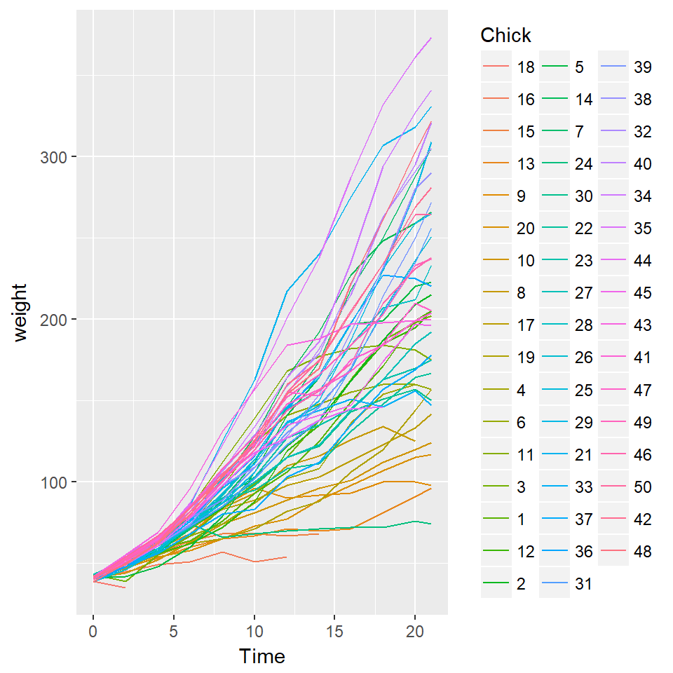

```r
> qplot(x=Time, y=weight, colour = Chick,
+       data = ChickWeight, geom = "line")
```

## Spaghetti plot: Facets

In ggplot2, if you want separate plots for something, these are referred to as facets.

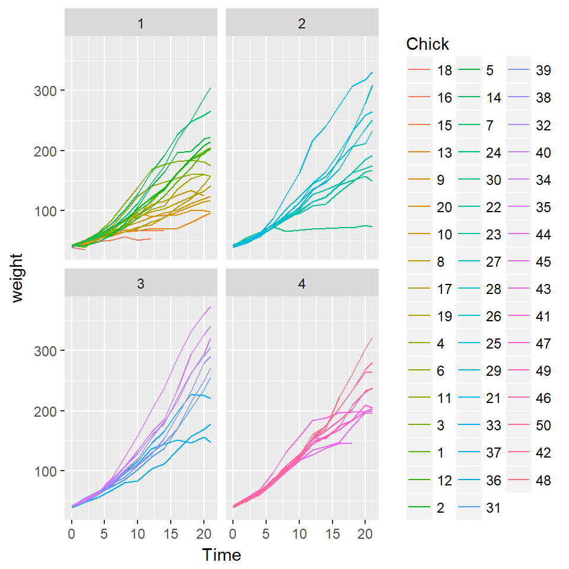

```r
> qplot(x = Time, y = weight, colour = Chick,
+       facets = ~Diet, data = ChickWeight, geom = "line")
```

## Spaghetti plot: Facets

We can turn off the legend (referred to a “guide” in ggplot2). (Note - there is different syntax with the `+`)

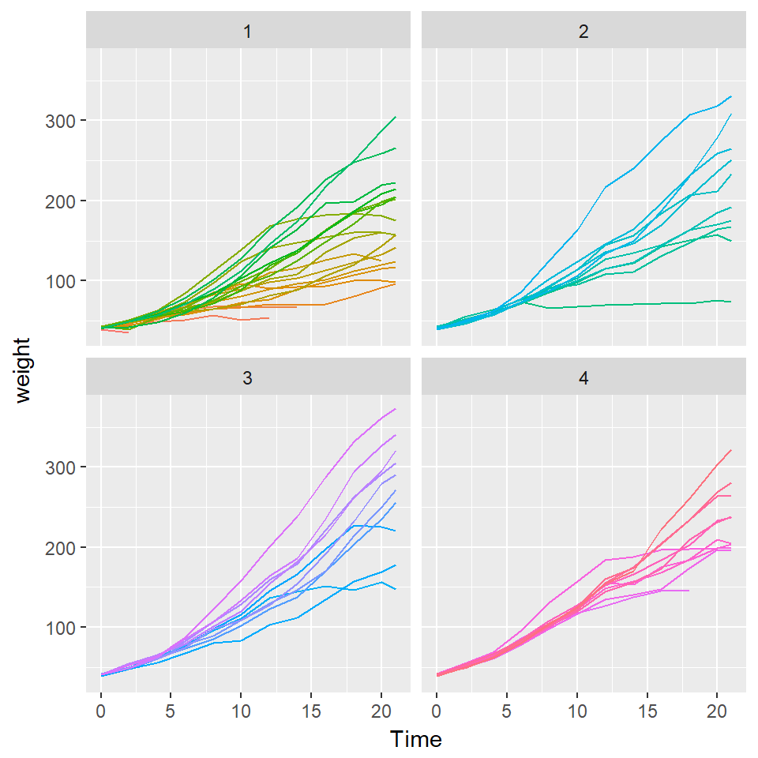

```r
> qplot(x=Time, y=weight, colour = Chick,
+       facets = ~ Diet,  data = ChickWeight,
+         geom = "line") + guides(colour=FALSE)
```

## Spaghetti plot: Facets

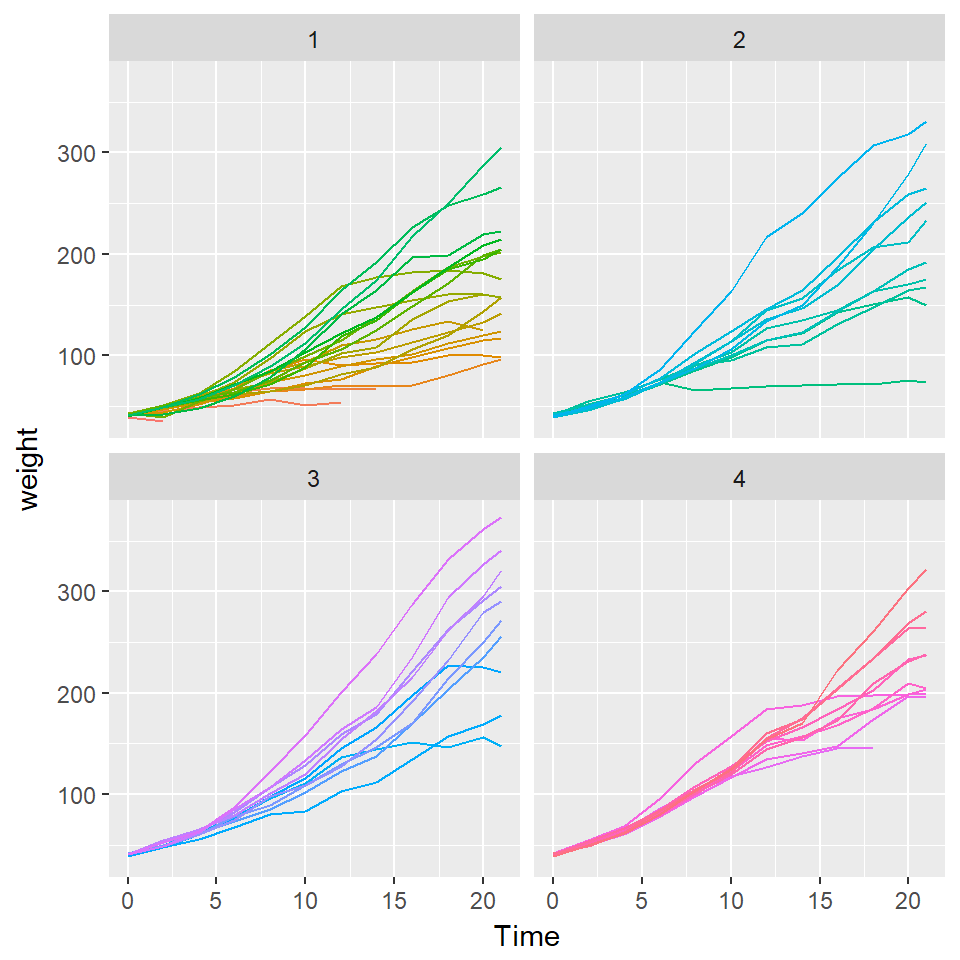

```r
> ggplot(aes(x = Time, y = weight, colour = Chick),
+     data = ChickWeight) + geom_line() +
+     facet_wrap(facets = ~Diet) + guides(colour = FALSE)
```

## ggplot2

Let’s try this out on the childhood mortality data used above. However, let’s do some manipulation first, by using `gather` on the data to convert to long.

```r
library(tidyr)
long = death
long$state = rownames(long)
long = long %>% gather(year, deaths, -state)
head(long, 2)
```

```
##         state  year deaths
## 1 Afghanistan X1760     NA
## 2     Albania X1760     NA
```

## ggplot2

Let’s also make the year numeric, as we did above in the stand-alone `year` variable.

```r
library(stringr)
library(dplyr)
long$year = long$year %>% str_replace("^X", "") %>% as.numeric
long = long %>% filter(!is.na(deaths))
```

## ggplot2

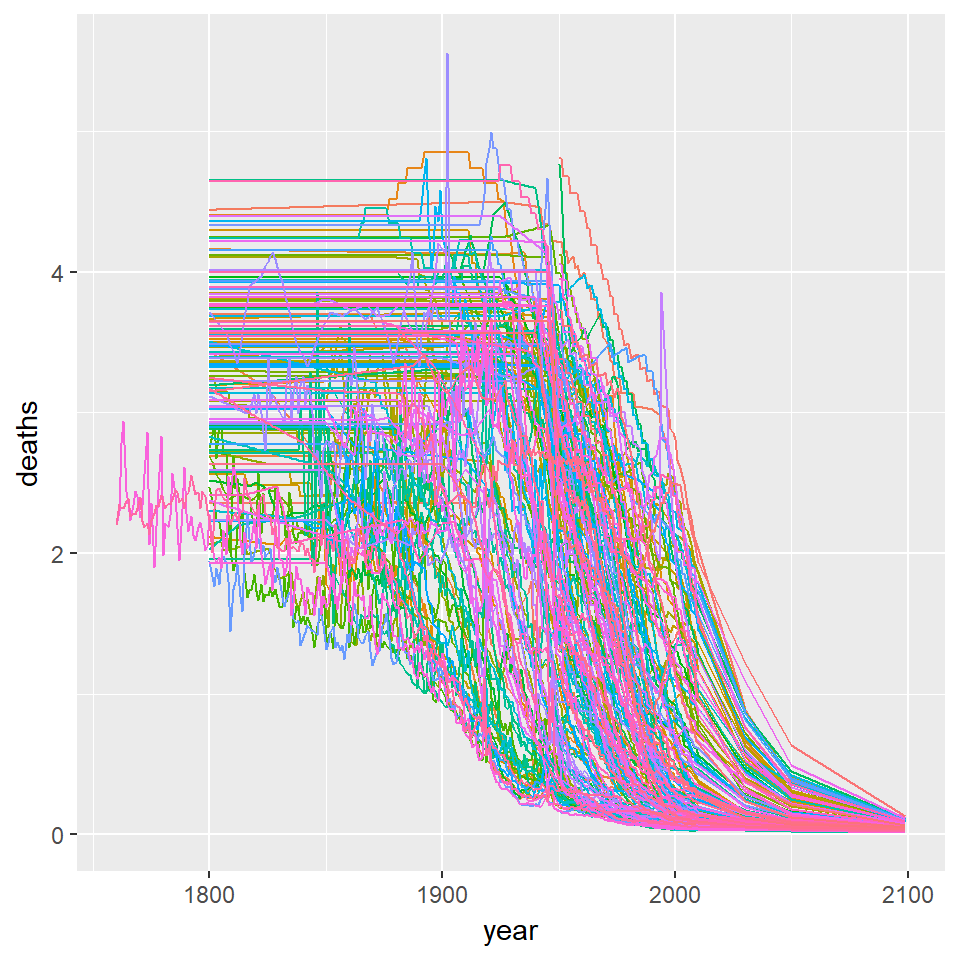

```r
> qplot(x = year, y = deaths, colour = state,
+     data = long, geom = "line") + guides(colour = FALSE)
```

## ggplot2

Let’s try to make it different like base R, a bit. We use `tile` for the geometric unit:

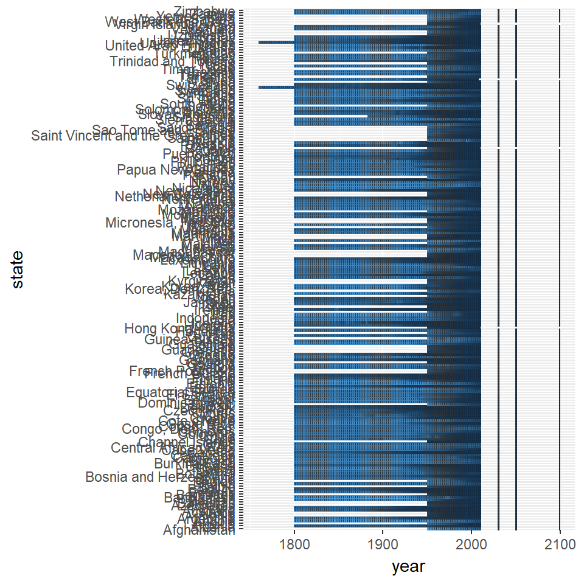

```r
qplot(x = year, y = state, colour = deaths,
    data = long, geom = "tile") + guides(colour = FALSE)
```

## ggplot2

Useful links:

- http://docs.ggplot2.org/0.9.3/index.html
- http://www.cookbook-r.com/Graphs/

# Part 2

## ggplot2

## Agenda

This lecture continues our introduction to the `ggplot2` package developed by Hadley Wickham.

Let’s begin by loading the packages we’ll use this class

```r
library(ggplot2)
library(MASS)  # Useful for data sets
library(plyr)  # We'll need mapvalues
```

## Review of ggplot2 basics

ggplot2 has a slightly steeper learning curve than the base graphics functions, but it also generally produces far better and more easily customizable graphics.

There are two basic calls in ggplot:

- `qplot(x, y, ..., data)`: a “quick-plot” routine, which essentially replaces the base `plot()`
- `ggplot(data, aes(x, y, ...), ...)`: defines a graphics object from which plots can be generated, along with *aesthetic mappings* that specify how variables are mapped to visual properties.

## ggplot function

The `ggplot2` library comes with a dataset called `diamonds`. Let’s look at it

```r
dim(diamonds)
```

```
## [1] 53940    10
```

```r
head(diamonds)
```

```
## # A tibble: 6 x 10
##   carat       cut color clarity depth table price     x     y     z
##   <dbl>     <ord> <ord>   <ord> <dbl> <dbl> <int> <dbl> <dbl> <dbl>
## 1  0.23     Ideal     E     SI2  61.5    55   326  3.95  3.98  2.43
## 2  0.21   Premium     E     SI1  59.8    61   326  3.89  3.84  2.31
## 3  0.23      Good     E     VS1  56.9    65   327  4.05  4.07  2.31
## 4  0.29   Premium     I     VS2  62.4    58   334  4.20  4.23  2.63
## 5  0.31      Good     J     SI2  63.3    58   335  4.34  4.35  2.75
## 6  0.24 Very Good     J    VVS2  62.8    57   336  3.94  3.96  2.48
```

It is a data frame of 53,940 diamonds, recording their attributes such as carat, cut, color, clarity, and price.

We will make a scatterplot showing the price as a function of the carat (size). (The data set is large so the plot may take a few moments to generate.)

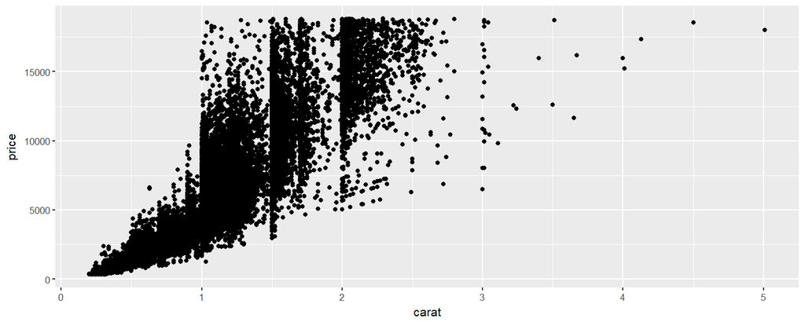

```r
diamond.plot <- ggplot(data=diamonds, aes(x=carat, y=price))
diamond.plot + geom_point()
```

The data set looks a little weird because a lot of diamonds are concentrated on the 1, 1.5 and 2 carat mark.

Let’s take a step back and try to understand the ggplot syntax.

1. The first thing we did was to define a graphics object, `diamond.plot`. This definition told R that we’re using the `diamonds` data, and that we want to display `carat` on the x-axis, and `price` on the y-axis.
2. We then called `diamond.plot + geom_point()` to get a scatterplot.

The arguments passed to `aes()` are called **mappings**. Mappings specify what variables are used for what purpose. When you use `geom_point()` in the second line, it pulls `x`, `y`, `colour`, `size`, etc., from the **mappings** specified in the `ggplot()` command.

You can also specify some arguments to `geom_point` directly if you want to specify them for each plot separately instead of pre-specifying a default.

Here we shrink the points to a smaller size, and use the `alpha` argument to make the points transparent.

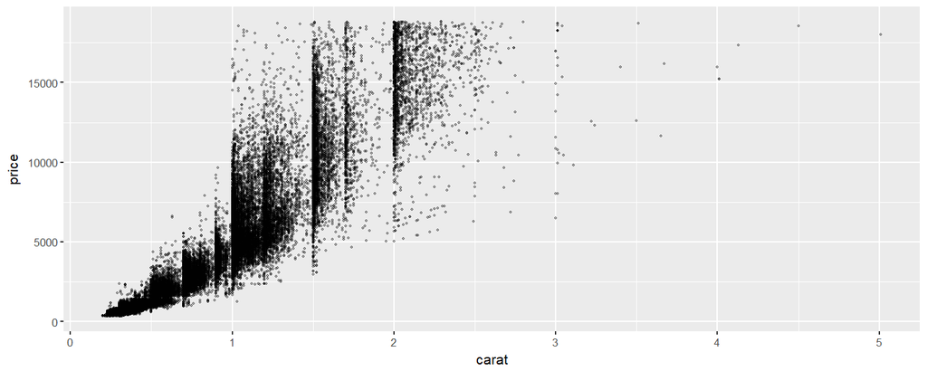

```r
diamond.plot + geom_point(size = 0.7, alpha = 0.3)
```

If we wanted to let point color depend on the color indicator of the diamond, we could do so in the following way.

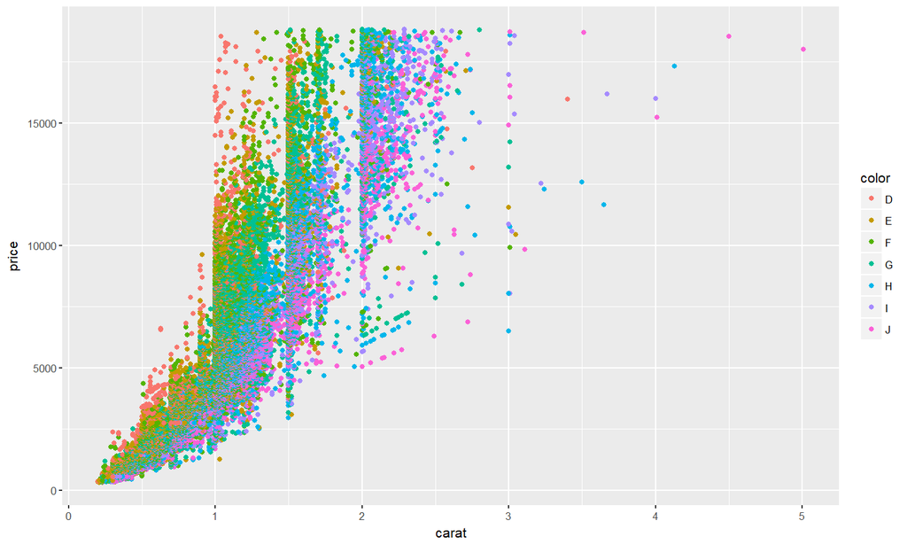

```r
diamond.plot <- ggplot(data=diamonds, aes(x=carat, y=price, colour = color))
diamond.plot + geom_point()
```

If we didn’t know anything about diamonds going in, this plot would indicate to us that **D** is likely the highest diamond grade, while **J** is the lowest grade.

We can change colors by specifying a different color palette. Here’s how we can switch to the `cbPalette` we saw last class.

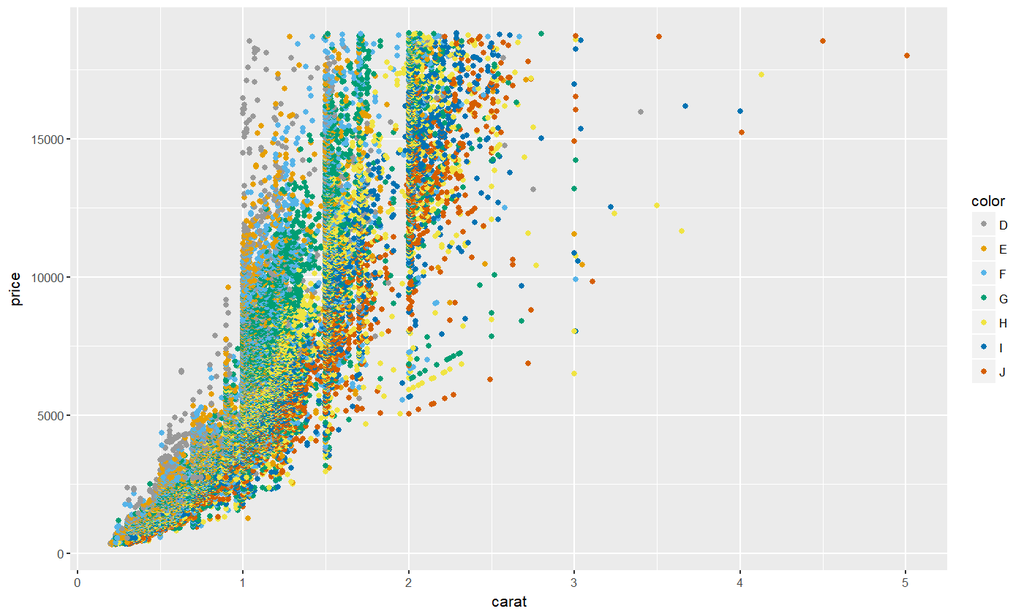

```r
cbPalette <- c("#999999", "#E69F00", "#56B4E9", "#009E73", "#F0E442", "#0072B2", "#D55E00", "#CC79A7")
diamond.plot <- ggplot(data=diamonds, aes(x=carat, y=price, colour = color))
diamond.plot + geom_point() + scale_colour_manual(values=cbPalette)
```

To make the scatterplot look more typical, we can switch to logarithmic coordinate axis spacing.

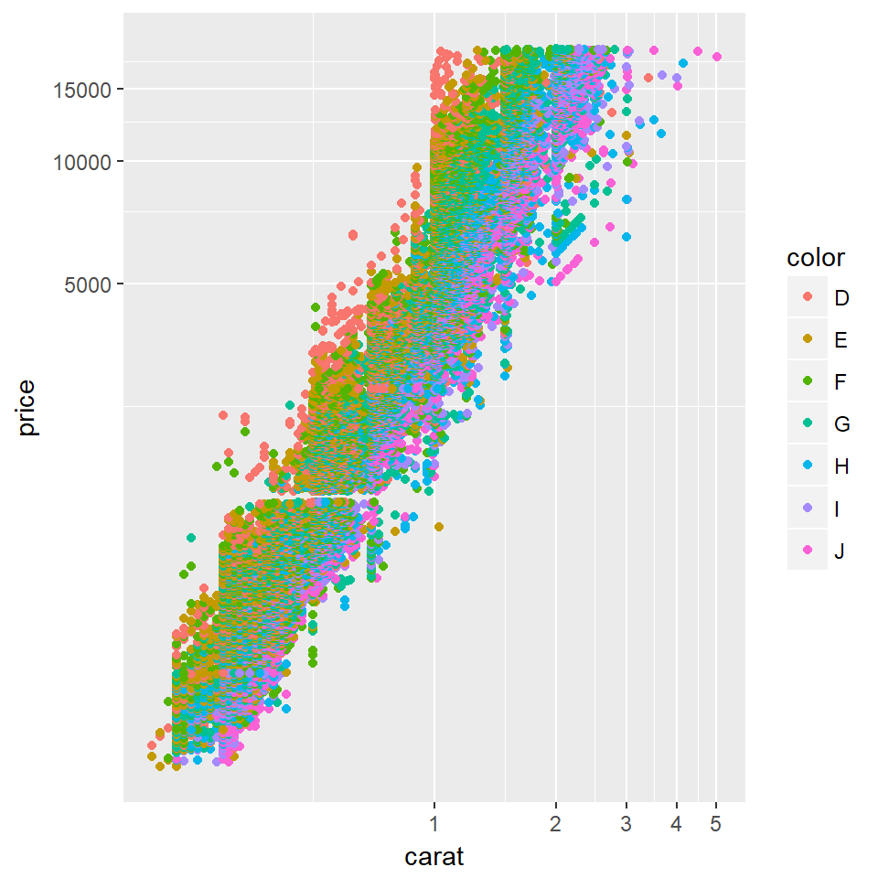

```r
diamond.plot + geom_point() +
  coord_trans(x = "log10", y = "log10")
```

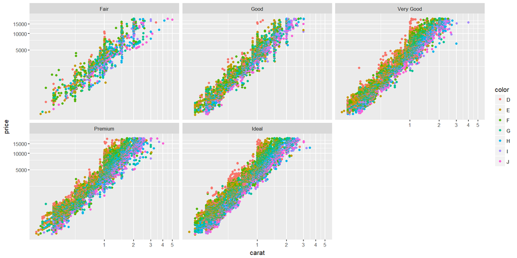

```r
diamond.plot <- ggplot(data=diamonds, aes(x=carat, y=price, colour = color))

diamond.plot + geom_point() + facet_wrap(~ cut) +
  coord_trans(x = "log10", y = "log10")
```

You can also use `facet_grid()` to produce this type of output.

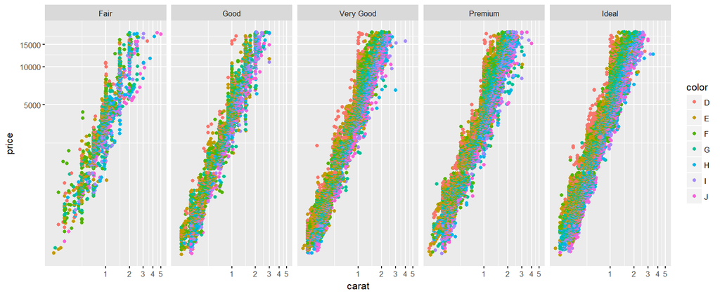

```r
diamond.plot + geom_point() + facet_grid(. ~ cut) +
  coord_trans(x = "log10", y = "log10")
```

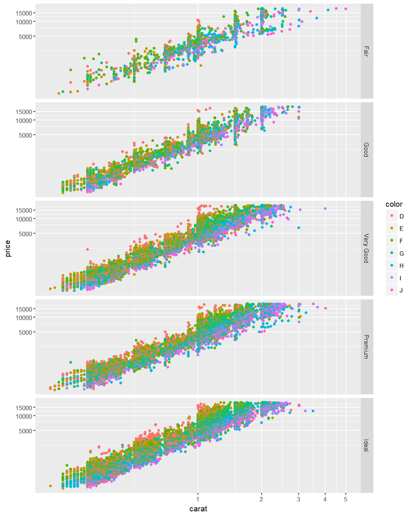

```r
diamond.plot + geom_point() + facet_grid(cut ~ .) +
  coord_trans(x = "log10", y = "log10")
```

`ggplot` can create a lot of different kinds of plots, just like lattice. Here are some examples.

| Function | Description |
| --- | --- |
| `geom_point(...)` | Points, i.e., scatterplot |
| `geom_bar(...)` | Bar chart |
| `geom_line(...)` | Line chart |
| `geom_boxplot(...)` | Boxplot |
| `geom_violin(...)` | Violin plot |
| `geom_density(...)` | Density plot with one variable |
| `geom_density2d(...)` | Density plot with two variables |
| `geom_histogram(...)` | Histogram |

## A barchart example

We’ll use the `birthwt` data for this example, so let’s start by loading an cleaning it. All of this code is borrowed from Lecture 5.

```r
# Assign better variable names
colnames(birthwt) <- c("birthwt.below.2500", "mother.age", "mother.weight",
    "race", "mother.smokes", "previous.prem.labor", "hypertension", "uterine.irr",
    "physician.visits", "birthwt.grams")

# Assign better labels to categorical variables
birthwt <- transform(birthwt,
            race = as.factor(mapvalues(race, c(1, 2, 3),
                              c("white","black", "other"))),
            mother.smokes = as.factor(mapvalues(mother.smokes,
                              c(0,1), c("no", "yes"))),
            hypertension = as.factor(mapvalues(hypertension,
                              c(0,1), c("no", "yes"))),
            uterine.irr = as.factor(mapvalues(uterine.irr,
                              c(0,1), c("no", "yes"))),
            birthwt.below.2500 = as.factor(mapvalues(birthwt.below.2500,
                              c(0,1), c("no", "yes")))
            )
```

## A bar chart

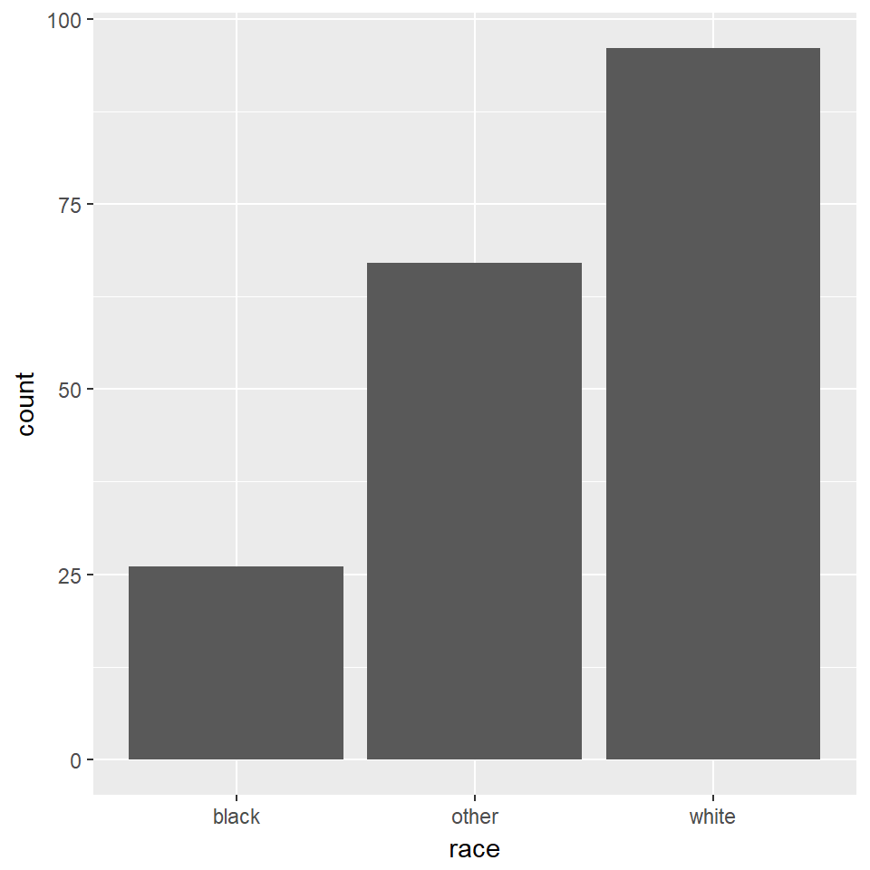

```r
qplot(x = race, data = birthwt, geom = "bar")
```

## Histograms and density plots

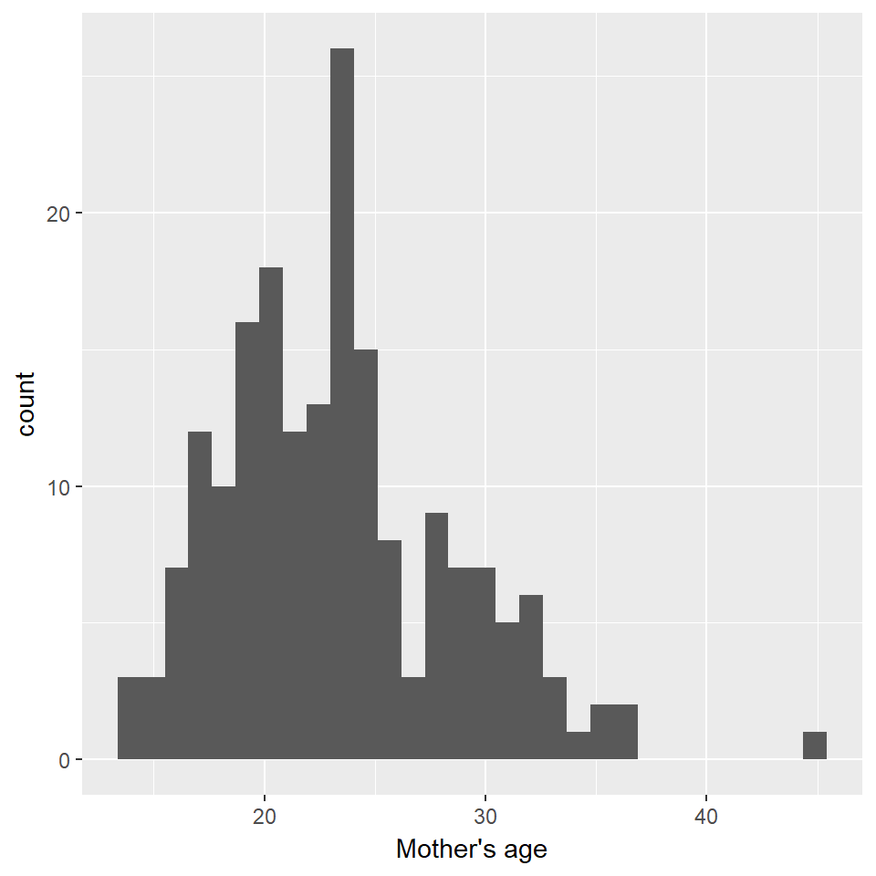

```r
base.plot <- ggplot(birthwt, aes(x = mother.age)) +
  xlab("Mother's age")
base.plot + geom_histogram()
```

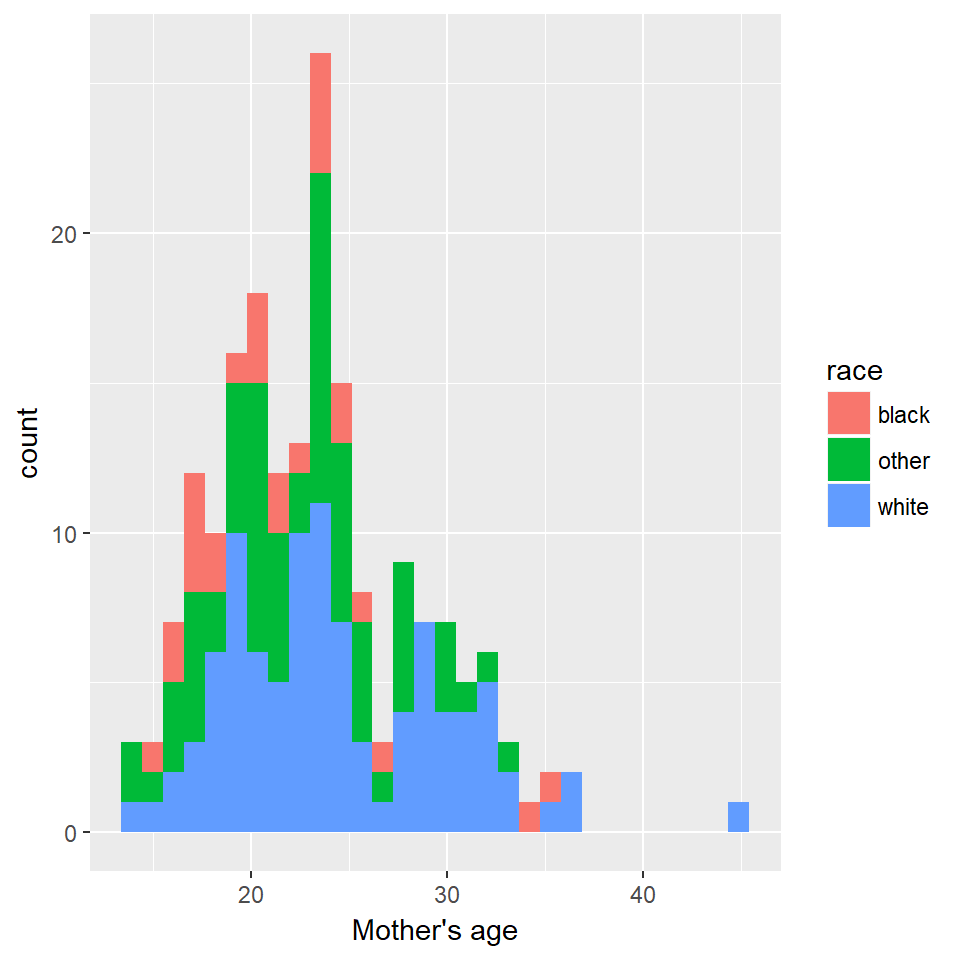

```r
base.plot + geom_histogram(aes(fill = race))
```

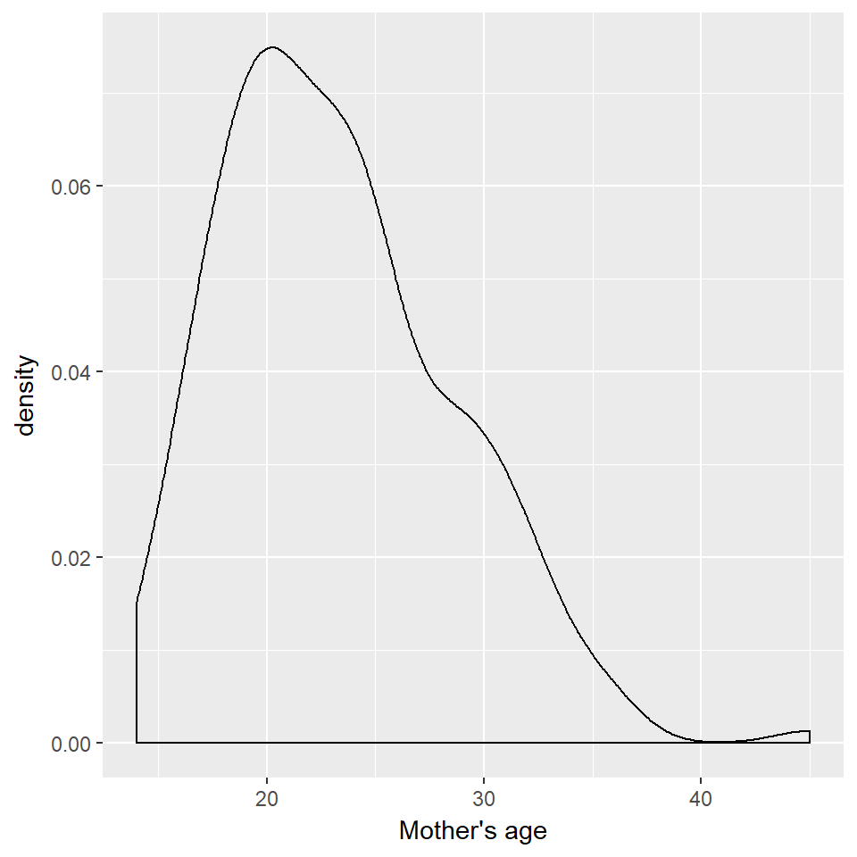

```r
base.plot + geom_density()
```

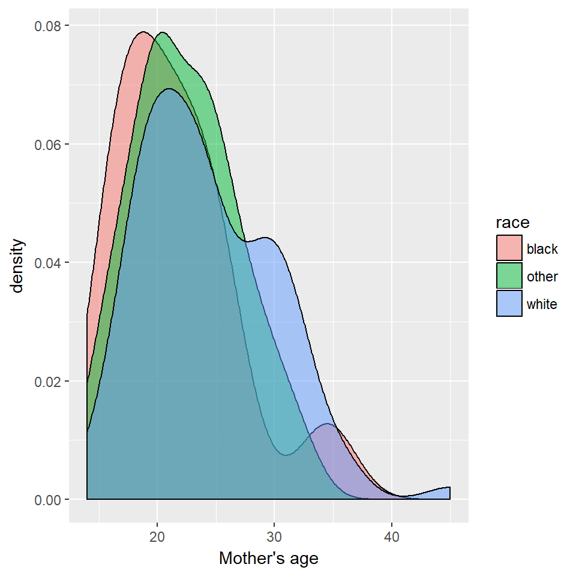

```r
base.plot + geom_density(aes(fill = race), alpha = 0.5)
```

## Box plots and violin plots

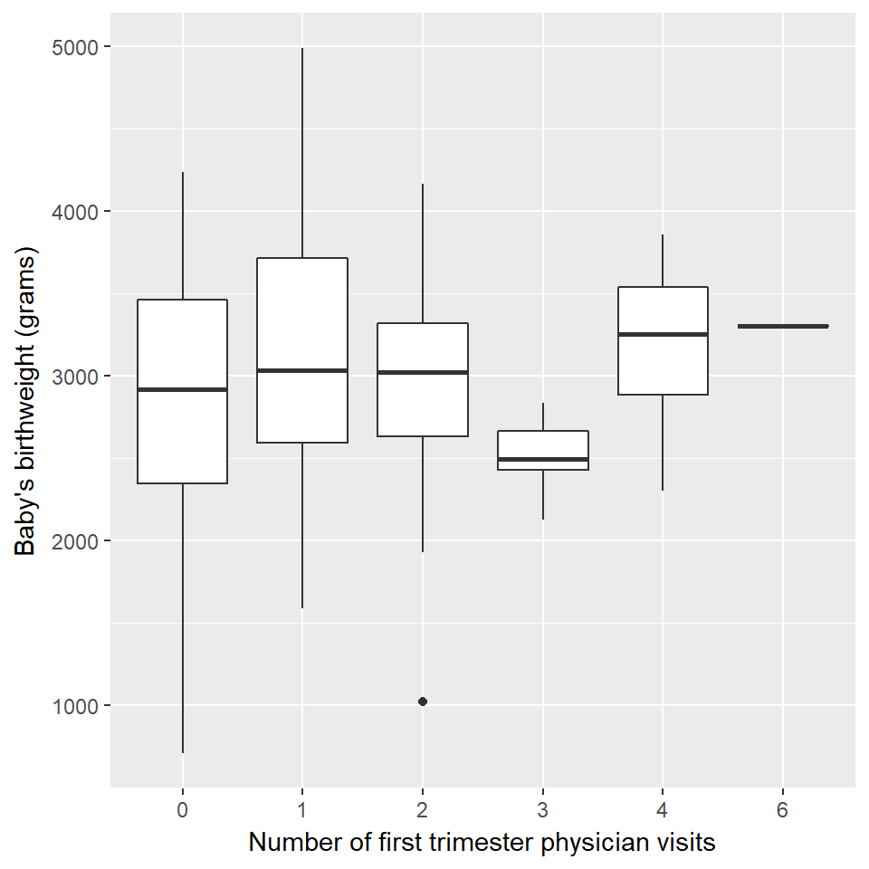

```r
base.plot <- ggplot(birthwt, aes(x = as.factor(physician.visits), y = birthwt.grams)) +
  xlab("Number of first trimester physician visits") +
  ylab("Baby's birthweight (grams)")

# Box plot
base.plot + geom_boxplot()
```

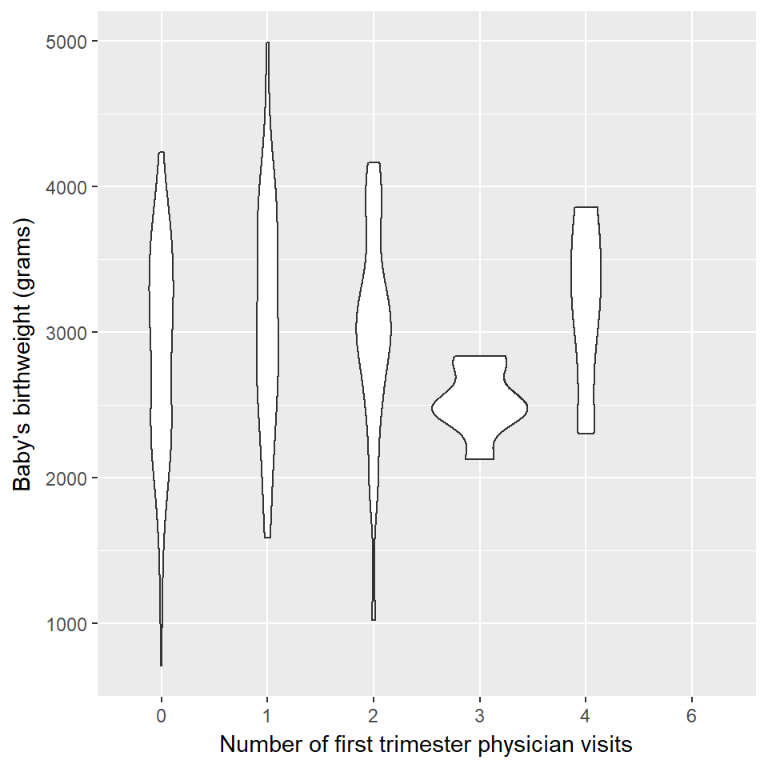

```r
# Violin plot
base.plot + geom_violin()
```

## Visualizing means

Previously we calculated the following table:

```r
bwt.summary <- aggregate(birthwt.grams ~ race + mother.smokes, data = birthwt, FUN = mean) # aggregate
bwt.summary
```

```
##    race mother.smokes birthwt.grams
## 1 black            no      2854.500
## 2 other            no      2815.782
## 3 white            no      3428.750
## 4 black           yes      2504.000
## 5 other           yes      2757.167
## 6 white           yes      2826.846
```

We can plot this table in a nice bar chart as follows:

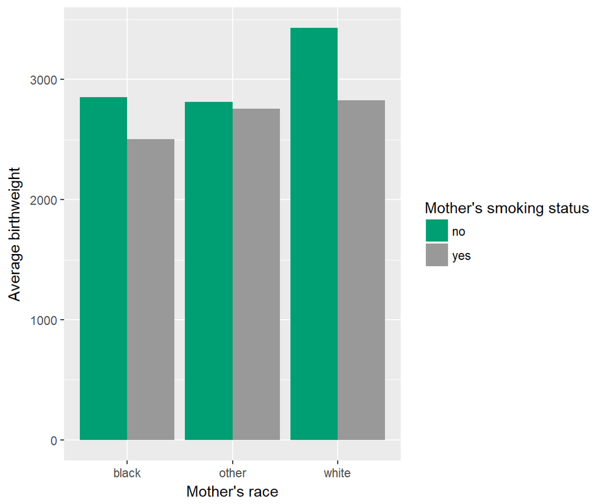

```r
# Define basic aesthetic parameters
p.bwt <- ggplot(data = bwt.summary, aes(y = birthwt.grams, x = race, fill = mother.smokes))

# Pick colors for the bars
bwt.colors <- c("#009E73", "#999999")

# Display barchart
p.bwt + geom_bar(stat = "identity", position = "dodge") +
  ylab("Average birthweight") +
  xlab("Mother's race") +
  guides(fill = guide_legend(title = "Mother's smoking status")) +
  scale_fill_manual(values=bwt.colors)
```

## Statistical overlays in ggplot

One of the main advantages of `ggplot` is that it makes it really easy to overlay model fits, confidence bars, etc. We’ll get more practice with this next week, when we talk more about how to do statistical inference in R.

For the time being, let’s just display a scatterplot smoother.

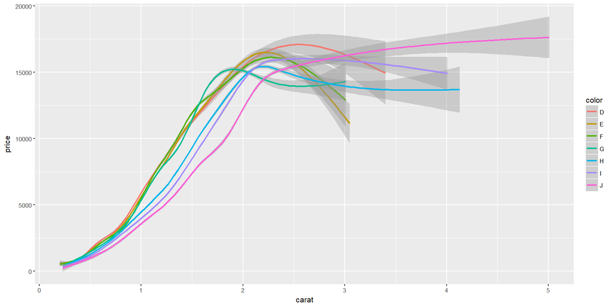

```r
diamond.plot + stat_smooth()
```

This shows curves modelling the relationship between diamond size in carats and price for the different diamond colours.

We could use the `geom_point()` command to also display the underlying points, but that would make the curves difficult to see. Let’s try it anyway.

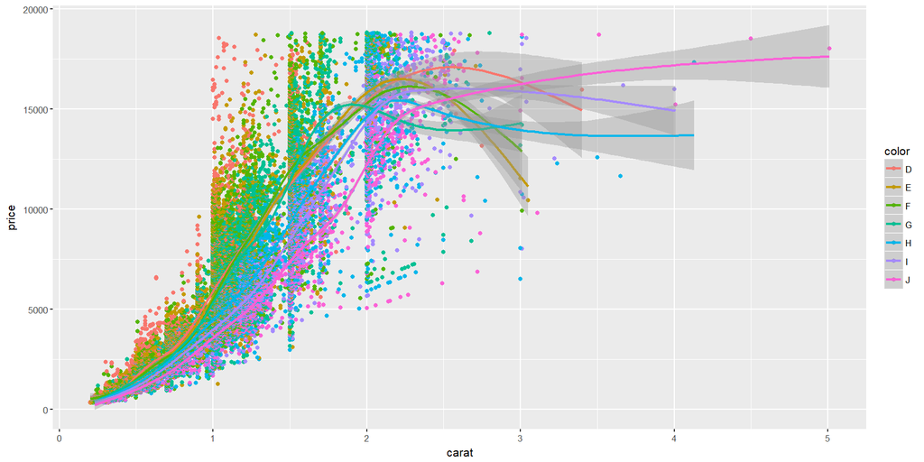

```r
diamond.plot + geom_point() + stat_smooth()
```

We can make this look better by decreasing the point opacity so that the trend curves aren’t so obscured.

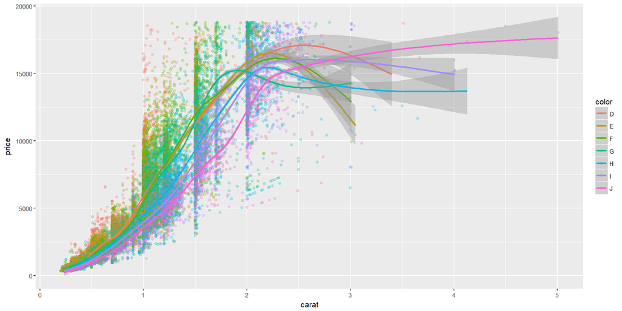

```r
diamond.plot + geom_point(size = 1.5, alpha = 0.25) + stat_smooth()
```

## Birthweight regression overlay

In addition to the more flexible smoother in the example above, we can also overlay more structured summaries such as regression curves.

Here’s the plot that we saw at the end of Lecture 5, which makes good use of regression line overlays.

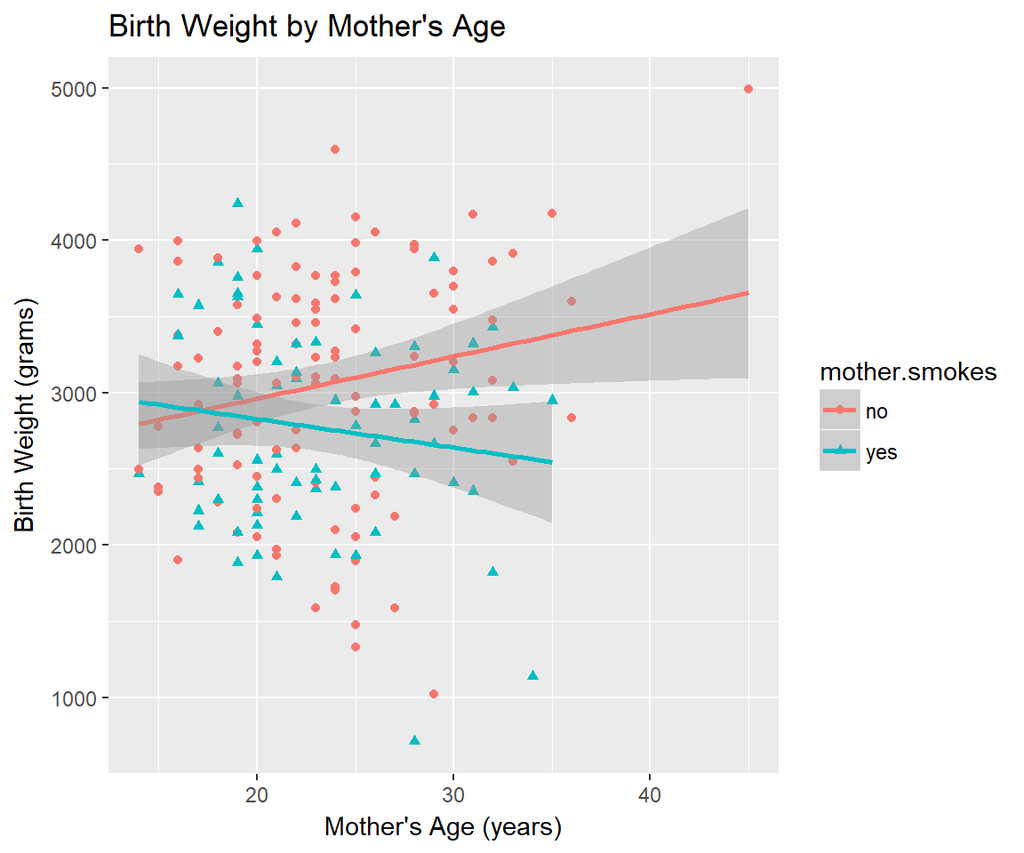

```r
ggplot(birthwt, aes(x=mother.age, y=birthwt.grams, shape=mother.smokes, color=mother.smokes)) +
  geom_point() + # Adds points (scatterplot)
  geom_smooth(method = "lm") + # Adds regression lines
  ylab("Birth Weight (grams)") + # Changes y-axis label
  xlab("Mother's Age (years)") + # Changes x-axis label
  ggtitle("Birth Weight by Mother's Age") # Changes plot title
```

Recall that when we calculated correlations between birth weight and mother’s age, we got the following results.

```r
by(data = birthwt[c("birthwt.grams", "mother.age")],
   INDICES = birthwt["mother.smokes"],
   FUN = function(x) {cor(x[,1], x[,2])})
```

```
## mother.smokes: no
## [1] 0.2014558
## --------------------------------------------------------
## mother.smokes: yes
## [1] -0.1441649
```

This tells us that the association between mother’s age and the baby’s birthweight seems to depend on the mother’s smoking status. Among mothers that smoke, this association is negative (older mothers tend to give birth to lower weight babies), while among mothers that don’t smoke, the association is positive.

We can read off the same conclusions more simply from the plot. The regression lines capture the association between birthweight and mother’s age. The fact that the observed points are very spread out around the regression lines visually conveys the fact that the correlation between birthweight and mother’s age is not very large.

## Is that an outlier?

The plot shows us something that the correlation calculation cannot: there’s a non-smoking mother who was 45 years old when she gave birth, and the combination of her age and the baby’s weight (around 5000g) are well outside the range of all other data points. Let’s see what happens when we remove this observation and re-plot.

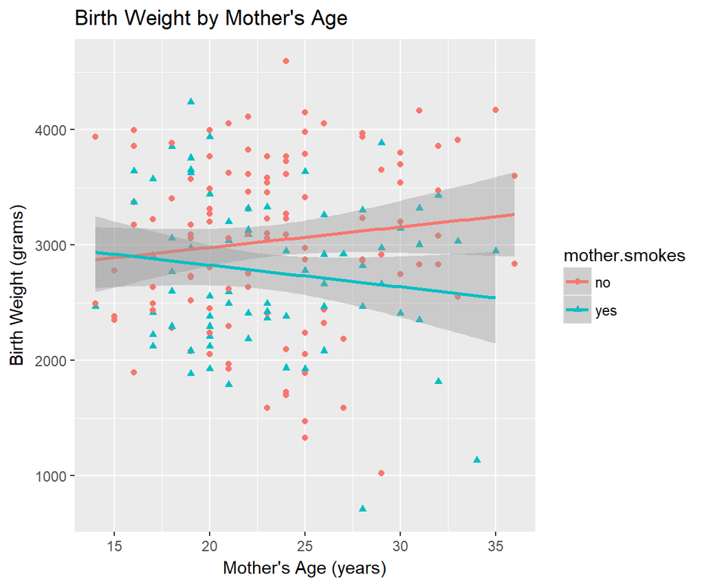

```r
# Get new data set that no longer contains the outlier
birthwt.sub <- subset(birthwt, subset = mother.age < 40)

ggplot(birthwt.sub, aes(x=mother.age, y=birthwt.grams, shape=mother.smokes, color=mother.smokes)) +
  geom_point() + # Adds points (scatterplot)
  geom_smooth(method = "lm") + # Adds regression lines
  ylab("Birth Weight (grams)") + # Changes y-axis label
  xlab("Mother's Age (years)") + # Changes x-axis label
  ggtitle("Birth Weight by Mother's Age") # Changes plot title
```

The general trends appear to be qualitatively the same, but the association in the non-smoking group appears to be far less strong than we were led to believe when we still had the outlying point in our data.

## ggplot2 also does maps

We’ll need the `maps` library for this example.

```r
library(maps)
```

One of the data sets that comes with R is the `USArrests` data

```r
head(USArrests)
```

```
##            Murder Assault UrbanPop Rape
## Alabama      13.2     236       58 21.2
## Alaska       10.0     263       48 44.5
## Arizona       8.1     294       80 31.0
## Arkansas      8.8     190       50 19.5
## California    9.0     276       91 40.6
## Colorado      7.9     204       78 38.7
```

Here’s how we can get a headmap of Murder rates (per 100,000 population) on a map of the US.

## map#1

```r
# Create data frame for map data (US states)
states <- map_data("state")

# Here's what the states data frame looks like
str(states)
```

```
## 'data.frame':    15537 obs. of  6 variables:
##  $ long     : num  -87.5 -87.5 -87.5 -87.5 -87.6 ...
##  $ lat      : num  30.4 30.4 30.4 30.3 30.3 ...
##  $ group    : num  1 1 1 1 1 1 1 1 1 1 ...
##  $ order    : int  1 2 3 4 5 6 7 8 9 10 ...
##  $ region   : chr  "alabama" "alabama" "alabama" "alabama" ...
##  $ subregion: chr  NA NA NA NA ...
```

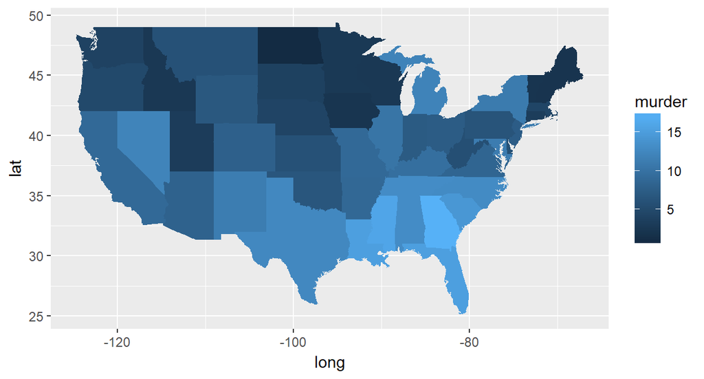

```r
# Make a copy of the data frame to manipulate
arrests <- USArrests

# Convert everything to lower case
names(arrests) <- tolower(names(arrests))
arrests$region <- tolower(rownames(USArrests))

# Merge the map data with the arrests data based on region
choro <- merge(states, arrests, sort = FALSE, by = "region")
choro <- choro[order(choro$order), ]

# Plot a map, filling in the states based on murder rate
qplot(long, lat, data = choro, group = group, fill = murder,
  geom = "polygon")
```

Essentially what’s happening here is that the map data (here called `states`) includes the latitute and longitude coordinates for the boundaries of each state. Specifying `geom = "polygon"` in the `qplot` function results in the states being traced out based on the lat/long coordinates. The `arrests` data provides crime rates for all the states, which allows us to color each polygon (state) based on the murder rate.

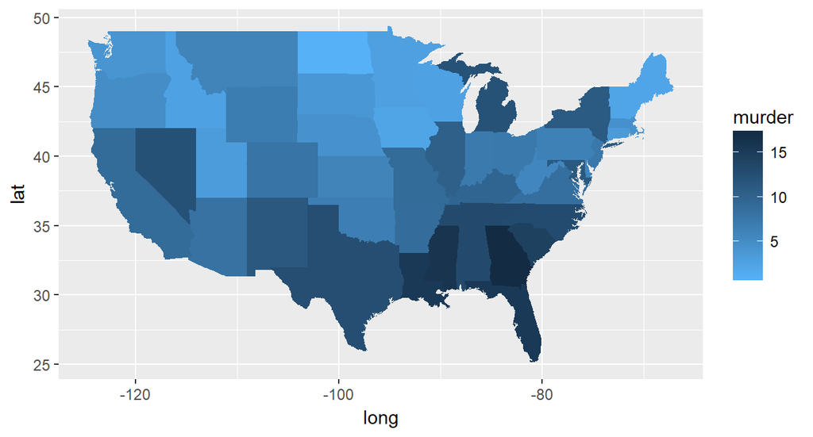

```r
qplot(long, lat, data = choro, group = group, fill = murder,
  geom = "polygon") +
  scale_fill_gradient(low = "#56B1F7", high = "#132B43")
```

All we’ve done here is swapped the defaults for `low` and `high`.